# NBA Draft: First-Round Prediction — Logistic Regression Baseline

Group project

2026-10-23

## Goal

Predict whether a college player is taken in the **first round** from his final college season (plus simple multi-season features). This is the baseline the other four models (KNN, ANN, random forest, XGBoost) are compared against.

Evaluation is **leave-one-draft-out**: train on every other draft class, predict the held-out class. Never random row splits — players from the same class leak.

## Data

```r
df <- read_csv(params$data, show_col_types = FALSE)

# Core feature set agreed by the team (see data/data_dictionary.csv for definitions).
# Dummies / flags listed in `binary_features` are not z-scored.
features <- c(
  # profile
  "class_num",            # Fr=1 ... Sr=4 (age proxy; younger = more valuable)
  "height_vs_pos",        # height relative to position average (swap for "height_in" to compare)
  "pos_wing", "pos_big",  # position dummies, guard = reference
  "recruit_rank", "unranked",
  "transfer",
  # role / load
  "mpg", "usg",
  # efficiency and shooting
  "TS_per", "FT_per", "TPA_rate", "TP_per_shrunk", "ftr", "pts_per40",
  # playmaking / rebounding / defense
  "ast_tov", "ORB_per", "DRB_per", "stl_per", "blk_per",
  # all-in-one impact
  "obpm", "dbpm",
  # competition level
  "team_adj_em"
)
binary_features <- c("pos_wing", "pos_big", "unranked", "transfer", "power_conf")
features <- intersect(features, names(df))

cat("Rows:", nrow(df), "  first-rounders:", sum(df$first_round),
    "  drafts:", n_distinct(df$draft_year), "\n")
```

```
## Rows: 12095   first-rounders: 353   drafts: 14
```

```r
df |> count(draft_year, first_round) |>
  pivot_wider(names_from = first_round, values_from = n, names_prefix = "fr_") |>
  kable(caption = "Rows per draft year (fr_1 = first-rounders)")
```

Rows per draft year (fr_1 = first-rounders)

| draft_year | fr_0 | fr_1 |
| --- | --- | --- |
| 2010 | 829 | 29 |
| 2011 | 871 | 24 |
| 2012 | 793 | 29 |
| 2013 | 823 | 23 |
| 2014 | 844 | 24 |
| 2015 | 851 | 26 |
| 2016 | 853 | 22 |
| 2017 | 827 | 27 |
| 2018 | 879 | 27 |
| 2019 | 851 | 26 |
| 2022 | 733 | 25 |
| 2023 | 770 | 25 |
| 2024 | 756 | 22 |
| 2025 | 1062 | 24 |

## Preprocessing

Missing values: median-impute and add a `_missing` flag. Then z-score each stat **within its draft year** so the model isn’t confused by era shifts in pace and 3-point volume.

```r
flag_cols <- character()
for (f in features) {
  if (anyNA(df[[f]])) {
    flag <- paste0(f, "_missing")
    df[[flag]] <- as.integer(is.na(df[[f]]))
    df[[f]]    <- ifelse(is.na(df[[f]]), median(df[[f]], na.rm = TRUE), df[[f]])
    flag_cols  <- c(flag_cols, flag)
  }
}

# Stats that mostly reflect position (a center blocks 5x more shots than a guard).
# These are standardized within position x season, so they read "good at this
# FOR YOUR POSITION". Everything else is standardized within season only.
pos_relative_features <- c("blk_per", "stl_per", "ORB_per", "DRB_per", "treb_per40",
                           "AST_per", "ast_tov", "ast_per40", "TPA_rate", "TP_per_shrunk",
                           "TPA_per40", "rim_rate", "dunks_per40", "height_in")
zs <- function(x) { s <- sd(x, na.rm = TRUE); if (is.na(s) || s == 0) 0 * x else (x - mean(x, na.rm = TRUE)) / s }

if (params$season_z) {
  z_feats   <- setdiff(features, binary_features)
  z_pos     <- intersect(z_feats, pos_relative_features)
  z_season  <- setdiff(z_feats, z_pos)
  df <- df |> mutate(position = ifelse(is.na(position), "unknown", position))
  df <- df |> group_by(draft_year) |> mutate(across(all_of(z_season), zs)) |> ungroup()
  if (length(z_pos))
    df <- df |> group_by(draft_year, position) |> mutate(across(all_of(z_pos), zs)) |> ungroup()
  cat("Standardized within position x season:", paste(z_pos, collapse = ", "), "\n")
}
```

```
## Standardized within position x season: TPA_rate, TP_per_shrunk, ast_tov, ORB_per, DRB_per, stl_per, blk_per
```

```r
x_cols <- c(features, flag_cols)
# Drop anything constant (glm would return NA for it)
const <- x_cols[sapply(df[x_cols], function(v) sd(v, na.rm = TRUE) == 0 | all(is.na(v)))]
if (length(const)) { cat("Dropping constant features:", paste(const, collapse = ", "), "\n"); x_cols <- setdiff(x_cols, const) }
cat("Features:", paste(x_cols, collapse = ", "), "\n")
```

```
## Features: class_num, height_vs_pos, pos_wing, pos_big, recruit_rank, unranked, transfer, mpg, usg, TS_per, FT_per, TPA_rate, TP_per_shrunk, ftr, pts_per40, ast_tov, ORB_per, DRB_per, stl_per, blk_per, obpm, dbpm, team_adj_em, class_num_missing, mpg_missing, pts_per40_missing, ast_tov_missing
```

## Helper: metrics

```r
pr_auc <- function(y, p) {           # average precision
  o <- order(-p); y <- y[o]
  tp <- cumsum(y); prec <- tp / seq_along(y)
  sum(prec * y) / max(sum(y), 1)
}
roc_auc <- function(y, p) {
  if (length(unique(y)) < 2) return(NA_real_)
  r <- rank(p); n1 <- sum(y == 1); n0 <- sum(y == 0)
  (sum(r[y == 1]) - n1 * (n1 + 1) / 2) / (n1 * n0)
}
log_loss <- function(y, p, eps = 1e-15) {
  p <- pmin(pmax(p, eps), 1 - eps); -mean(y * log(p) + (1 - y) * log(1 - p))
}
```

## Leave-one-draft-out logistic regression

Class imbalance is handled with weights (positives up-weighted so both classes sum to the same total). The model is plain `glm`; regularized alternatives (`glmnet`) are a natural next step.

```r
fit_weighted_glm <- function(train, x_cols) {
  y <- train$first_round
  w <- ifelse(y == 1, 0.5 / mean(y == 1), 0.5 / mean(y == 0))   # "balanced" weights
  form <- as.formula(paste("first_round ~", paste(x_cols, collapse = " + ")))
  suppressWarnings(glm(form, data = train, family = binomial(), weights = w))
}

# Leave-one-draft-out: returns per-year metrics and out-of-sample predictions
run_lodo <- function(df, x_cols) {
  preds <- rep(NA_real_, nrow(df)); per_year <- list()
  for (yr in sort(unique(df$draft_year))) {
    tr <- df |> filter(draft_year != yr); te_idx <- which(df$draft_year == yr)
    mu <- sapply(tr[x_cols], mean); sdv <- sapply(tr[x_cols], sd); sdv[sdv == 0 | is.na(sdv)] <- 1
    scale_df <- function(d) { d[x_cols] <- sweep(sweep(d[x_cols], 2, mu), 2, sdv, "/"); d }
    m <- fit_weighted_glm(scale_df(tr), x_cols)
    p <- predict(m, newdata = scale_df(df[te_idx, ]), type = "response")
    preds[te_idx] <- p
    y <- df$first_round[te_idx]; n_fr <- sum(y)
    if (n_fr == 0) next
    hits <- sum(y[order(-p)][seq_len(n_fr)])
    per_year[[as.character(yr)]] <- tibble(
      draft_year = yr, n_rows = length(te_idx), n_first_round = n_fr,
      pr_auc = pr_auc(y, p), roc_auc = roc_auc(y, p), log_loss = log_loss(y, p),
      top_n_hits = hits, top_n_precision = hits / n_fr)
  }
  list(per_year = bind_rows(per_year), preds = preds)
}

# Standardized coefficients from a fit on all years
full_coefs <- function(df, x_cols) {
  mu <- sapply(df[x_cols], mean); sdv <- sapply(df[x_cols], sd); sdv[sdv == 0 | is.na(sdv)] <- 1
  d <- df; d[x_cols] <- sweep(sweep(d[x_cols], 2, mu), 2, sdv, "/")
  m <- fit_weighted_glm(d, x_cols)
  tibble(feature = names(coef(m)), coef = coef(m)) |> filter(feature != "(Intercept)", !is.na(coef)) |>
    arrange(desc(coef))
}

overall_table <- function(df, res) {
  y <- df$first_round; p <- res$preds
  tibble(metric = c("PR-AUC", "baseline PR-AUC (positive rate)", "ROC-AUC", "log loss", "top-n precision (mean over drafts)"),
         value  = c(pr_auc(y, p), mean(y), roc_auc(y, p), log_loss(y, p), mean(res$per_year$top_n_precision)))
}
```

### Pass 1: all features

```r
res1   <- run_lodo(df, x_cols)
coefs1 <- full_coefs(df, x_cols)
kable(overall_table(df, res1), digits = 3, caption = "Pass 1 — overall")
```

Pass 1 — overall

| metric | value |
| --- | --- |
| PR-AUC | 0.807 |
| baseline PR-AUC (positive rate) | 0.029 |
| ROC-AUC | 0.990 |
| log loss | 0.121 |
| top-n precision (mean over drafts) | 0.731 |

```r
kable(coefs1, digits = 3, caption = "Pass 1 — standardized coefficients")
```

Pass 1 — standardized coefficients

| feature | coef |
| --- | --- |
| team_adj_em | 1.749 |
| mpg | 1.316 |
| pos_big | 1.088 |
| obpm | 0.845 |
| pos_wing | 0.780 |
| height_vs_pos | 0.692 |
| blk_per | 0.662 |
| usg | 0.614 |
| stl_per | 0.465 |
| pts_per40 | 0.438 |
| DRB_per | 0.340 |
| TPA_rate | 0.231 |
| recruit_rank | 0.214 |
| TP_per_shrunk | 0.199 |
| TS_per | 0.175 |
| ftr | 0.074 |
| FT_per | 0.045 |
| ast_tov | 0.019 |
| ORB_per | -0.039 |
| class_num_missing | -0.051 |
| mpg_missing | -0.094 |
| transfer | -0.153 |
| dbpm | -0.248 |
| unranked | -0.263 |
| class_num | -1.590 |

### Pass 2: drop the 3 weakest features

Backward elimination, one step: remove the three features with the smallest absolute standardized coefficient (missing-value flags are not candidates), refit. This is the final model.

```r
n_drop <- 3
candidates <- coefs1 |> filter(!str_detect(feature, "_missing$")) |> arrange(abs(coef))
dropped <- head(candidates$feature, n_drop)
cat("Dropped:", paste(sprintf("%s (%.3f)", dropped, candidates$coef[seq_len(n_drop)]), collapse = ", "), "\n")
```

```
## Dropped: ast_tov (0.019), ORB_per (-0.039), FT_per (0.045)
```

```r
x_final <- setdiff(x_cols, dropped)
res   <- run_lodo(df, x_final)
coefs <- full_coefs(df, x_final)
per_year <- res$per_year
df$p_first_round <- res$preds

kable(per_year, digits = 3, caption = "Final model — per-draft results (leave-one-draft-out)")
```

Final model — per-draft results (leave-one-draft-out)

| draft_year | n_rows | n_first_round | pr_auc | roc_auc | log_loss | top_n_hits | top_n_precision |
| --- | --- | --- | --- | --- | --- | --- | --- |
| 2010 | 858 | 29 | 0.819 | 0.993 | 0.120 | 20 | 0.690 |
| 2011 | 895 | 24 | 0.803 | 0.989 | 0.101 | 17 | 0.708 |
| 2012 | 822 | 29 | 0.810 | 0.984 | 0.101 | 22 | 0.759 |
| 2013 | 846 | 23 | 0.854 | 0.994 | 0.108 | 18 | 0.783 |
| 2014 | 868 | 24 | 0.871 | 0.985 | 0.103 | 19 | 0.792 |
| 2015 | 877 | 26 | 0.952 | 0.997 | 0.104 | 22 | 0.846 |
| 2016 | 875 | 22 | 0.727 | 0.991 | 0.149 | 16 | 0.727 |
| 2017 | 854 | 27 | 0.917 | 0.996 | 0.118 | 21 | 0.778 |
| 2018 | 906 | 27 | 0.789 | 0.990 | 0.143 | 19 | 0.704 |
| 2019 | 877 | 26 | 0.736 | 0.992 | 0.169 | 17 | 0.654 |
| 2022 | 758 | 25 | 0.778 | 0.982 | 0.151 | 17 | 0.680 |
| 2023 | 795 | 25 | 0.748 | 0.985 | 0.147 | 17 | 0.680 |
| 2024 | 778 | 22 | 0.759 | 0.991 | 0.127 | 15 | 0.682 |
| 2025 | 1086 | 24 | 0.894 | 0.993 | 0.069 | 19 | 0.792 |

```r
kable(overall_table(df, res), digits = 3, caption = "Final model — overall")
```

Final model — overall

| metric | value |
| --- | --- |
| PR-AUC | 0.809 |
| baseline PR-AUC (positive rate) | 0.029 |
| ROC-AUC | 0.990 |
| log loss | 0.121 |
| top-n precision (mean over drafts) | 0.734 |

### Position check: is the model over-picking bigs?

For each draft class, take the model’s top-n (n = number of real first-rounders that year) and compare its position mix with the real first round. If the “model top-n” share for bigs is well above the “actual” share, the model is over-paying for size.

```r
pos_check <- df |> group_by(draft_year) |>
  mutate(n_fr = sum(first_round), in_model_topn = rank(-p_first_round, ties.method = "first") <= n_fr) |>
  ungroup() |>
  group_by(position) |>
  summarise(pool_share       = n() / nrow(df),
            actual_1st_round = sum(first_round),
            model_topn       = sum(in_model_topn),
            hits_in_topn     = sum(in_model_topn & first_round == 1), .groups = "drop") |>
  mutate(actual_share = actual_1st_round / sum(actual_1st_round),
         model_share  = model_topn / sum(model_topn),
         precision    = hits_in_topn / model_topn) |>
  select(position, pool_share, actual_1st_round, actual_share, model_topn, model_share, precision)
kable(pos_check, digits = 3, caption = "Position mix: pool vs. actual first round vs. model's top-n")
```

Position mix: pool vs. actual first round vs. model’s top-n

| position | pool_share | actual_1st_round | actual_share | model_topn | model_share | precision |
| --- | --- | --- | --- | --- | --- | --- |
| big | 0.291 | 134 | 0.380 | 153 | 0.433 | 0.693 |
| guard | 0.354 | 87 | 0.246 | 78 | 0.221 | 0.731 |
| wing | 0.354 | 132 | 0.374 | 122 | 0.346 | 0.787 |

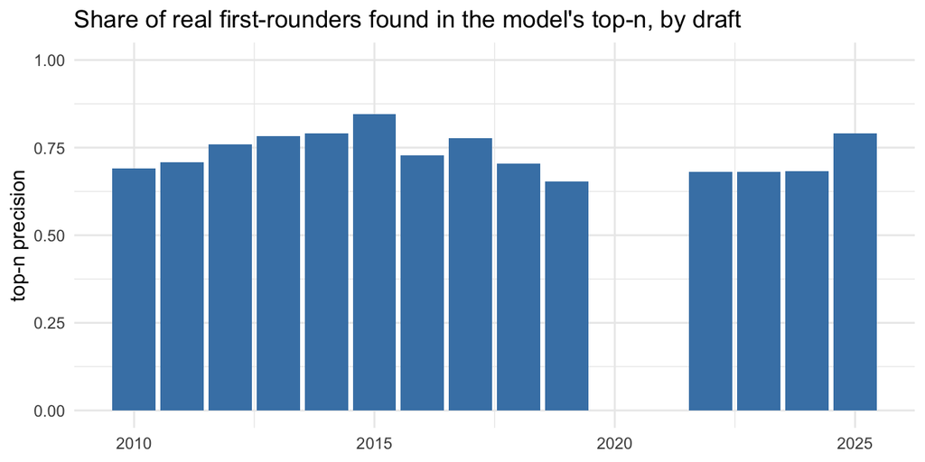

```r
ggplot(per_year, aes(draft_year, top_n_precision)) +
  geom_col(fill = "steelblue") + ylim(0, 1) +
  labs(title = "Share of real first-rounders found in the model's top-n, by draft",
       x = NULL, y = "top-n precision") + theme_minimal()
```

## Coefficients (final model)

Signs to check: `class_num` and `recruit_rank` negative (younger / higher-ranked recruits = more valuable), `obpm`, `height_vs_pos`, `usg` positive. If they’re wrong, it’s almost always a join problem — look at `match_report.txt` first.

Remember these are *conditional* effects: a negative coefficient on, say, `ORB_per` means “given height and position, extra offensive rebounding doesn’t add first-round value”, not that rebounding is bad.

On height: the model uses `height_vs_pos` (height relative to the position average) rather than raw height, so “tall” means tall *for a guard* or tall *for a big*. If height still dominates, check the “Non-first-rounders the model liked most” table below: if it’s full of 7-footers with weak stats, the model is over-paying for size and a position × height interaction or a cap is the next step.

```r
kable(coefs, digits = 3, caption = "Standardized coefficients (+ = more likely first round)")
```

Standardized coefficients (+ = more likely first round)

| feature | coef |
| --- | --- |
| team_adj_em | 1.743 |
| mpg | 1.332 |
| pos_big | 1.066 |
| obpm | 0.852 |
| pos_wing | 0.775 |
| height_vs_pos | 0.691 |
| blk_per | 0.652 |
| usg | 0.634 |
| stl_per | 0.452 |
| pts_per40 | 0.427 |
| DRB_per | 0.329 |
| TPA_rate | 0.272 |
| recruit_rank | 0.214 |
| TP_per_shrunk | 0.201 |
| TS_per | 0.181 |
| ftr | 0.062 |
| class_num_missing | -0.050 |
| mpg_missing | -0.094 |
| transfer | -0.155 |
| dbpm | -0.236 |
| unranked | -0.260 |
| class_num | -1.588 |

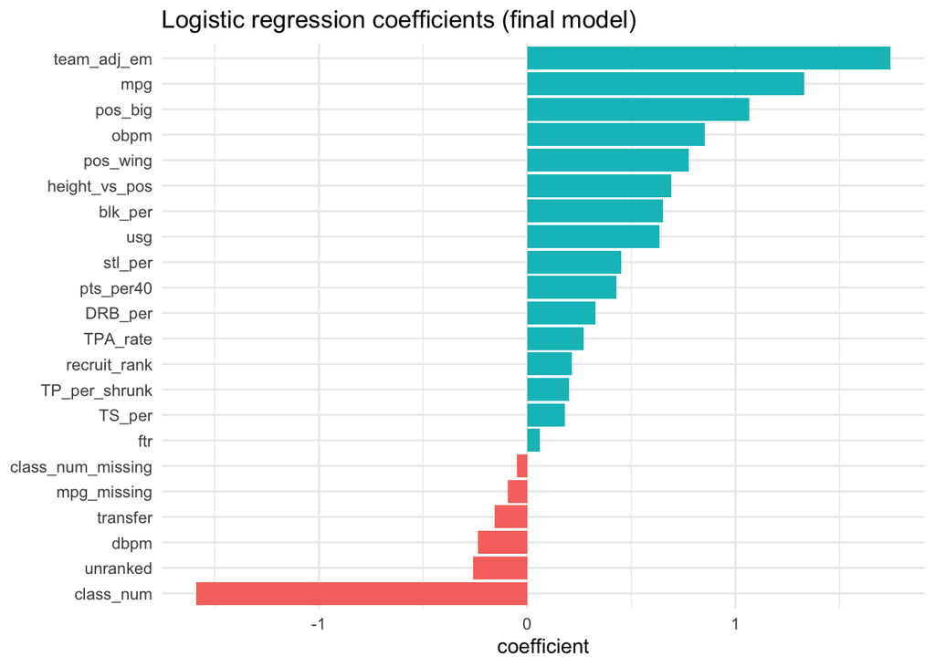

```r
ggplot(coefs, aes(reorder(feature, coef), coef, fill = coef > 0)) +
  geom_col(show.legend = FALSE) + coord_flip() +
  labs(x = NULL, y = "coefficient", title = "Logistic regression coefficients (final model)") + theme_minimal()
```

## Biggest disagreements with the draft

```r
df <- df |> group_by(draft_year) |>
  mutate(rank_in_class = rank(-p_first_round, ties.method = "first")) |> ungroup()
df <- df |> mutate(pick = ifelse(is.na(pick_number), "Undrafted", as.character(pick_number)))
show <- c("draft_year", "player_name", "school", "position", "ht", "class_year", "pick", "p_first_round", "rank_in_class")
show <- intersect(show, names(df))

df |> filter(first_round == 1) |> arrange(p_first_round) |> head(15) |> select(all_of(show)) |>
  kable(digits = 3, caption = "First-rounders the model liked least")
```

First-rounders the model liked least

| draft_year | player_name | school | position | ht | class_year | pick | p_first_round | rank_in_class |
| --- | --- | --- | --- | --- | --- | --- | --- | --- |
| 2012 | Miles Plumlee | Duke | big | 6-10 | Sr | 26 | 0.014 | 196 |
| 2014 | Josh Huestis | Stanford | big | 6-7 | Sr | 29 | 0.015 | 214 |
| 2022 | Patrick Baldwin Jr. | Milwaukee | big | 6-9 | Fr | 28 | 0.029 | 144 |
| 2012 | Festus Ezeli | Vanderbilt | big | 6-11 | Sr | 30 | 0.051 | 137 |
| 2022 | Peyton Watson | UCLA | big | 6-8 | Fr | 30 | 0.052 | 123 |
| 2025 | Cedric Coward | Washington St. | big | 6-6 | Sr | 11 | 0.070 | 138 |
| 2023 | Ben Sheppard | Belmont | wing | 6-6 | Sr | 26 | 0.098 | 107 |
| 2014 | C.J. Wilcox | Washington | wing | 6-5 | Sr | 28 | 0.187 | 92 |
| 2011 | Jimmy Butler | Marquette | wing | 6-6 | Sr | 30 | 0.210 | 87 |
| 2011 | Norris Cole | Cleveland St. | guard | 6-2 | Sr | 28 | 0.303 | 71 |
| 2023 | Marcus Sasser | Houston | guard | 6-2 | Sr | 25 | 0.407 | 66 |
| 2015 | Larry Nance Jr. | Wyoming | wing | 6-8 | Sr | 27 | 0.444 | 62 |
| 2025 | Yanic Konan Niederhauser | Penn St. | big | 7-0 | Jr | 30 | 0.462 | 50 |
| 2018 | Jerome Robinson | Boston College | guard | 6-5 | Jr | 13 | 0.499 | 71 |
| 2011 | Nolan Smith | Duke | guard | 6-2 | Sr | 21 | 0.591 | 51 |

```r
df |> filter(first_round == 0) |> arrange(desc(p_first_round)) |> head(15) |> select(all_of(show)) |>
  kable(digits = 3, caption = "Non-first-rounders the model liked most")
```

Non-first-rounders the model liked most

| draft_year | player_name | school | position | ht | class_year | pick | p_first_round | rank_in_class |
| --- | --- | --- | --- | --- | --- | --- | --- | --- |
| 2019 | Bol Bol | Oregon | big | 7-2 | Fr | 44 | 1.000 | 2 |
| 2024 | Kyle Filipowski | Duke | big | 7-0 | So | 32 | 1.000 | 3 |
| 2016 | Isaiah Whitehead | Seton Hall | guard | 6-4 | So | 42 | 1.000 | 4 |
| 2012 | Will Barton | Memphis | wing | 6-6 | So | 40 | 1.000 | 5 |
| 2023 | Trayce Jackson-Davis | Indiana | big | 6-9 | Jr | 57 | 0.999 | 5 |
| 2019 | Ignas Brazdeikis | Michigan | wing | 6-7 | Fr | 47 | 0.999 | 5 |
| 2018 | Gary Trent Jr. | Duke | wing | 6-6 | Fr | 37 | 0.999 | 10 |
| 2016 | Diamond Stone | Maryland | big | 6-11 | Fr | 40 | 0.998 | 8 |
| 2018 | De’Anthony Melton | USC | guard | 6-4 | Fr | 46 | 0.998 | 13 |
| 2022 | Christian Koloko | Arizona | big | 7-1 | So | 33 | 0.998 | 9 |
| 2010 | Hassan Whiteside | Marshall | big | 7-0 | Fr | 33 | 0.998 | 8 |
| 2018 | Jontay Porter | Missouri | big | 6-11 | Fr | Undrafted | 0.998 | 15 |
| 2018 | Tony Carr | Penn St. | guard | 6-5 | So | 51 | 0.997 | 16 |
| 2022 | Kendall Brown | Baylor | wing | 6-8 | Fr | 48 | 0.996 | 11 |
| 2023 | Azuolas Tubelis | Arizona | big | 6-11 | Jr | Undrafted | 0.996 | 15 |

## Save results

```r
write_csv(per_year, file.path(params$results_dir, "logreg_per_year.csv"))
write_csv(coefs,    file.path(params$results_dir, "logreg_coefficients.csv"))
df |> mutate(pick_number = ifelse(is.na(pick_number), "Undrafted", as.character(pick_number))) |>
  select(pid, player_name, school, position, ht, draft_year, class_year, first_round, pick_number, p_first_round, rank_in_class) |>
  write_csv(file.path(params$results_dir, "logreg_predictions.csv"))
```

## For the other four models

Reuse this exact loop: same `players.csv`, same leave-one-draft-out split, same metrics. Swap `fit_weighted_glm` for `class::knn`, `nnet::nnet`, `randomForest::randomForest`, or `xgboost::xgboost`. KNN and the ANN need the scaling; the tree models don’t (and xgboost takes NAs directly, so the imputation step can be skipped for it).